# Project: University Entrance Exam Analysis

Dol_R

8/24/2020

## Introduction and Key Takeaways

In Turkey, every year millions of students take the university entrance exam. After the announcement of results, participants list their university and department choices and they are placed according to their ranks.

This analysis focuses on universities and departments popularity over the years. Hopefully, it would help future participants in their decision making process.

**Key Takeaways:**

- Medicine maintained its popularity over the years.
- Koç University has a significantly higher popularity.

## Summary of the Data and Explanations

Using **University Exam** data from [*Hacettepe University’s Website*](http://web.ee.hacettepe.edu.tr/osym), we obtained university results of years 2016-2020. Each year is on a separate Excel spreadsheet. Since every year some departments are opened and some are shut down, datasets will have different number of rows. There are 9 variables and more than 10000 rows for each dataset.

**university**: Name of the university  
**city**: University’s location  
**department**: Name of the department  
**type**: Type of the exam  
**quota**: Maximum number of participants to be accepted, upper bound for accepted_number  
**accepted_number**: Accepted number of participants to the selected university’s selected department  
**lowest_score**: Lowest score of the accepted participant’s scores  
**highest_score**: Highest score of the accepted participant’s scores  
**lowest_ranking**: Lowest ranking of the accepted participant’s scores, last accepted person’s ranking

**Objectives:**

- Analyze University Exam Entrance data
- Cleaning and manipulation of datasets
- Exploration of the popularity trends of the universities and departments
- Comparison by visualization
- Finding top universities and departments

### Data Preprocessing

In order to ease the reading process, functions `mani97` and `mani86` are created. These functions remove the columns related to the percentage of change regarding the previous year. They also rename the columns and remove the last empty rows. The raw data for some years have an additional column at the end, therefore two functions were needed.

```r
knitr::opts_chunk$set(echo = TRUE, message=FALSE, warning=FALSE) # applies to all chunks
mani97 <- function(data){
  newdata <- data %>%
  rename(
    number = c(1),
    difference = c(2),
    university = c(3),
    city = c(4),
    department = c(5),
    type = c(6),
    quota = c(7),
    difference_quota = c(8),
    accepted_number = c(9),
    lowest_score = c(10),
    highest_score = c(11),
    lowest_ranking = c(12),
    difference_ranking = c(13)
  )  %>% select(-number, -difference, -difference_quota, -difference_ranking) %>% slice_head(n=nrow(data)-9)
  return(newdata)
}
mani86 <- function(data){
  newdata <- data %>%
  rename(
    number = c(1),
    difference = c(2),
    university = c(3),
    city = c(4),
    department = c(5),
    type = c(6),
    quota = c(7),
    difference_quota = c(8),
    accepted_number = c(9),
    lowest_score = c(10),
    highest_score = c(11),
    lowest_ranking = c(12)
  )  %>% select(-number, -difference, -difference_quota) %>% slice_head(n=nrow(data)-9)
  return(newdata)
}
```

After loading the required libraries, we download the .xlsx file from our project repository. After reading it, we remove the file.

```r
library(tidyverse)
library(lubridate)
library(tinytex)
library(readxl) # read_excel
library(tidyr)
library(httr) # GET
library(reshape2)
library(ggforce) # circle data points
url<-'https://github.com/pjournal/boun01g-dol-r/blob/gh-pages/uni_exam_project/uni_exam.xlsx?raw=true'
GET(url, write_disk(tf <- tempfile(fileext = ".xlsx")))
```

```r
raw_df20 <- read_excel(tf, sheet="20", skip=21)
raw_df19 <- read_excel(tf, sheet="19", skip=21)
raw_df18 <- read_excel(tf, sheet="18", skip=21)
raw_df17 <- read_excel(tf, sheet="17", skip=21)
raw_df16 <- read_excel(tf, sheet="16", skip=21)
file.remove(tf)
```

### Loading the Libraries and Datasets

We have 5 datasets for the last 5 years. Each dataset has 9 columns and they all have different number of rows. For example there are 10617 rows in dataset for the year 2020 and 11402 rows in dataset for the year 2019. Some departments or even universities may have been opened or closed.

```r
data2020 <- mani97(raw_df20)
data2020 <- mani97(raw_df20)
data2019 <- mani97(raw_df19)
data2018 <- mani86(raw_df18)
data2017 <- mani97(raw_df17)
data2016 <- mani97(raw_df16)

data2020 %>% summarise(exam20=n()) %>% mutate(data2019 %>% summarise(exam19=n())) %>% mutate(data2018 %>% summarise(exam18=n())) %>% mutate(data2017 %>% summarise(exam17=n())) %>% mutate(data2016 %>% summarise(exam16=n()))
```

```
## # A tibble: 1 x 5
##   exam20 exam19 exam18 exam17 exam16
##    <int>  <int>  <int>  <int>  <int>
## 1  10617  11402  11958  11484  10657
```

As an example, let’s observe dataset for the year 2018. First four variables are categorical and the rest is numerical. We could also see that there are 11958 rows for this year.

```r
data2018 %>% arrange(desc(lowest_score)) %>% glimpse()
```

```
## Rows: 11,958
## Columns: 9
## $ university      <chr> "İSTANBUL MEDİPOL ÜNİVERSİTESİ", "KOÇ ÜNİVERSİTESİ", …
## $ city            <chr> "İSTANBUL", "İSTANBUL", "İSTANBUL", "İSTANBUL", "İSTA…
## $ department      <chr> "Tıp Fakültesi (İngilizce) (Burslu)", "Tıp Fakültesi …
## $ type            <chr> "SAY", "SAY", "SAY", "SAY", "SAY", "SAY", "SAY", "SAY…
## $ quota           <dbl> 10, 15, 8, 11, 52, 82, 11, 30, 82, 50, 9, 175, 50, 12…
## $ accepted_number <dbl> 10, 15, 8, 11, 52, 82, 11, 30, 82, 50, 9, 175, 50, 12…
## $ lowest_score    <dbl> 549.1749, 548.1738, 543.2350, 542.8008, 538.5325, 536…
## $ highest_score   <dbl> 562.9543, 556.2859, 546.1979, 548.5940, 559.5140, 562…
## $ lowest_ranking  <dbl> 56, 84, 207, 221, 400, 496, 510, 511, 622, 637, 739, …
```

## Exploratory Data Analysis

When the exam procedure changes, the types of grading systems also change. Therefore, there is no point of comparing `type` variable for different years. But it can be an identifier in each year.

### Top Universities and Departments

Some universities’ departments may be selected by the participants with lowest scores in different types of grading systems. After grouping by `university` and `department`, lowest score column is put in decreasing order. Lowest score is the last entering person’s score to a specific university and department. By putting it into decreasing order, we get the highest scores of last entering people. Let’s see how the top 10 departments changed over the years.

To do this, we count unique values and use `full_join`. Finally, we replace `NULL` values with zero, which means this university or department was not in top 10 for that specific year.

```r
score <- function(data){
  data %>% group_by(university, department) %>% select(-type, -city) %>% arrange(desc(lowest_score)) %>% head(10) %>% mutate(department=replace(department, str_detect(department,"Tıp"), "Tıp")) %>% mutate(department=str_replace(department, "Burslu", "")) %>% mutate(department=str_replace(department, "İngilizce", "")) %>% mutate(department=str_replace(department, " \\([^()]{0,}\\)", "")) %>% mutate(department=str_replace(department, " \\([^()]{0,}\\)", "")) %>% ungroup()
}
dept <- function(data){
  data %>% count(department) %>% arrange(desc(n))
}
uni <- function(data){
  data %>% count(university) %>% arrange(desc(n))
}
```

```r
top_uni <- full_join(uni(score(data2016)), uni(score(data2017)), by="university", suffix=c(".2016", ".2017")) %>% full_join(., uni(score(data2018)), by="university", suffix=c(".2016", ".2018"))
top_uni <- full_join(top_uni, uni(score(data2019)), by="university", suffix=c(".2018", ".2019"))
top_uni <- full_join(top_uni, uni(score(data2020)), by="university", suffix=c(".2019", ".2020"))
names(top_uni)[names(top_uni)=='n.2016']<-'year2016'
names(top_uni)[names(top_uni)=='n.2017']<-'year2017'
names(top_uni)[names(top_uni)=='n.2018']<-'year2018'
names(top_uni)[names(top_uni)=='n.2019']<-'year2019'
names(top_uni)[names(top_uni)=='n']<-'year2020'

top_dept <- full_join(dept(score(data2016)), dept(score(data2017)), by="department", suffix=c(".2016", ".2017")) %>% full_join(., dept(score(data2018)), by="department", suffix=c(".2016", ".2018"))
top_dept <- full_join(top_dept, dept(score(data2019)), by="department", suffix=c(".2018", ".2019"))
top_dept <- full_join(top_dept, dept(score(data2020)), by="department", suffix=c(".2019", ".2020"))
names(top_dept)[names(top_dept)=='n.2016']<-'year2016'
names(top_dept)[names(top_dept)=='n.2017']<-'year2017'
names(top_dept)[names(top_dept)=='n.2018']<-'year2018'
names(top_dept)[names(top_dept)=='n.2019']<-'year2019'
names(top_dept)[names(top_dept)=='n']<-'year2020'
```

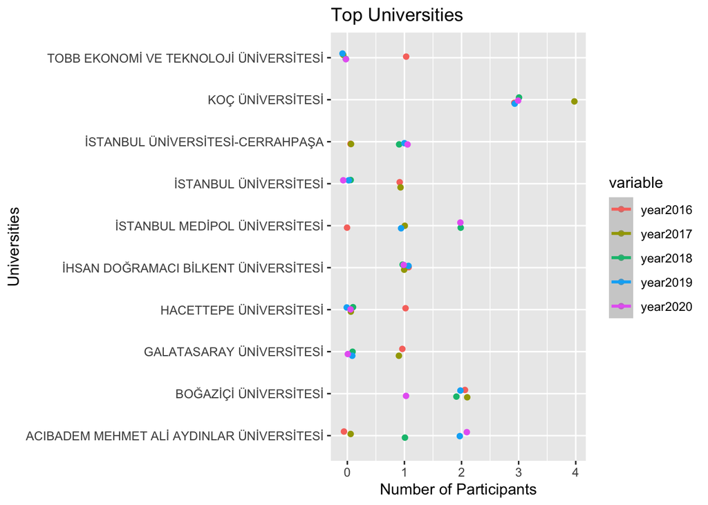

```r
top_uni <- top_uni %>% replace_na(list(year2016 = 0, year2017 = 0, year2018 = 0, year2019 = 0, year2020 = 0))
top_dept <- top_dept %>% replace_na(list(year2016 = 0, year2017 = 0, year2018 = 0, year2019 = 0, year2020 = 0))

top_uni.long <- melt(top_uni)
plot_uni <- ggplot(top_uni.long, aes(x=value, y=university, col=variable)) + geom_jitter(width=0.1, height=0.1)  + stat_smooth() + ggtitle("Top Universities") + xlab("Number of Participants") + ylab("Universities") + theme(plot.caption=element_text(hjust = 0.5))
plot_uni
```

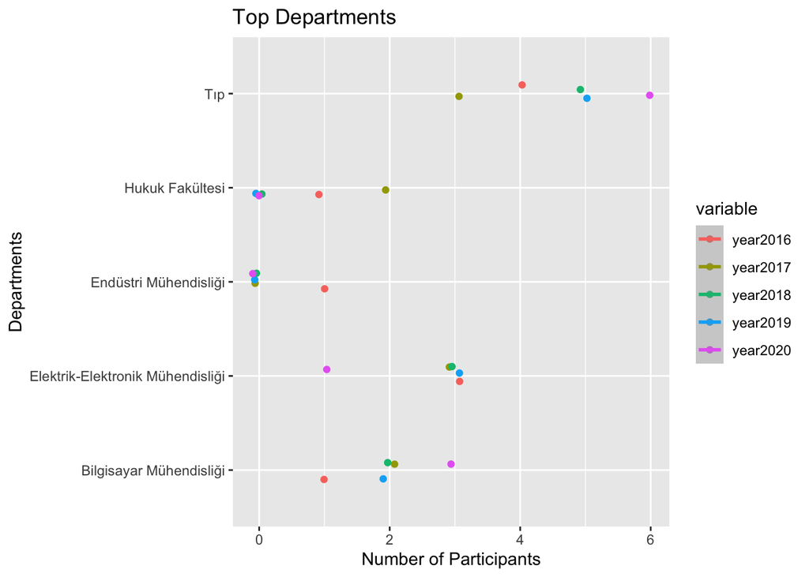

```r
top_dept.long <- melt(top_dept)
plot_dept <- ggplot(top_dept.long, aes(x=value, y=department, col=variable)) + geom_jitter(width=0.1, height=0.1) + stat_smooth() + ggtitle("Top Departments") + xlab("Number of Participants") + ylab("Departments") + theme(plot.caption=element_text(hjust = 0.5))
plot_dept
```

### Top Cities

```r
total_data <- full_join(data2016,data2017,by=c('university','department','city','type'),suffix = c('.2016','.2017'))%>%
  full_join(. ,data2018,by=c('university','department','city','type'))%>%
  full_join(. ,data2019,by=c('university','department','city','type'),suffix = c('.2018','.2019'))%>%
  full_join(. ,data2020,by=c('university','department','city','type'))
names(total_data)[names(total_data)=='type']<-'type.2020'
names(total_data)[names(total_data)=='quota']<-'quota.2020'
names(total_data)[names(total_data)=='accepted_number']<-'accepted_number.2020'
names(total_data)[names(total_data)=='lowest_score']<-'lowest_score.2020'
names(total_data)[names(total_data)=='highest_score']<-'highest_score.2020'
names(total_data)[names(total_data)=='lowest_ranking']<-'lowest_ranking.2020'
```

University and city distribution of the first thousand students in the university exam

```r
bin_tr<- total_data%>%
  filter(lowest_ranking.2020<1000)

tab2<-table(bin_tr$city,bin_tr$type.2020)
tab2
```

```
##
##            DİL EA SAY SÖZ
##   ANKARA     0  4   2   1
##   İSTANBUL   1 15   8   5
```

```r
tab<-table(bin_tr$university,bin_tr$type.2020)
tab
```

```
##
##                                             DİL EA SAY SÖZ
##   ACIBADEM MEHMET ALİ AYDINLAR ÜNİVERSİTESİ   0  0   2   0
##   BOĞAZİÇİ ÜNİVERSİTESİ                       0  3   2   1
##   GALATASARAY ÜNİVERSİTESİ                    0  1   0   0
##   İHSAN DOĞRAMACI BİLKENT ÜNİVERSİTESİ        0  3   2   0
##   İSTANBUL 29 MAYIS ÜNİVERSİTESİ              0  0   0   1
##   İSTANBUL MEDİPOL ÜNİVERSİTESİ               0  0   1   0
##   İSTANBUL ÜNİVERSİTESİ                       0  1   0   0
##   İSTANBUL ÜNİVERSİTESİ-CERRAHPAŞA            0  0   1   0
##   KOÇ ÜNİVERSİTESİ                            1  6   2   2
##   ÖZYEĞİN ÜNİVERSİTESİ                        0  1   0   1
##   SABANCI ÜNİVERSİTESİ                        0  2   0   0
##   TOBB EKONOMİ VE TEKNOLOJİ ÜNİVERSİTESİ      0  1   0   1
##   YEDİTEPE ÜNİVERSİTESİ                       0  1   0   0
```

University and city distribution of the first five thousand students in the university exam

```r
besbin_tr<- total_data%>%
  filter(lowest_ranking.2020<5000)

tab3<-table(besbin_tr$city,besbin_tr$type.2020)
tab3
```

```
##
##             DİL EA SAY SÖZ
##   ANKARA      9 19  21  10
##   ESKİŞEHİR   0  0   1   0
##   İSTANBUL   14 42  35  47
##   İZMİR       2  0   1   2
```

```r
tab4<-table(besbin_tr$university,besbin_tr$type.2020)
tab4
```

```
##
##                                             DİL EA SAY SÖZ
##   ACIBADEM MEHMET ALİ AYDINLAR ÜNİVERSİTESİ   0  0   2   0
##   ANKARA ÜNİVERSİTESİ                         0  1   2   0
##   BAHÇEŞEHİR ÜNİVERSİTESİ                     0  2   1   7
##   BAŞKENT ÜNİVERSİTESİ                        1  0   2   1
##   BEYKENT ÜNİVERSİTESİ                        0  0   0   1
##   BEZM-İ ÂLEM VAKIF ÜNİVERSİTESİ              0  0   1   0
##   BOĞAZİÇİ ÜNİVERSİTESİ                       4  7   4   3
##   EGE ÜNİVERSİTESİ                            0  0   1   0
##   ESKİŞEHİR TEKNİK ÜNİVERSİTESİ               0  0   1   0
##   GALATASARAY ÜNİVERSİTESİ                    1  5   0   1
##   GAZİ ÜNİVERSİTESİ                           0  0   2   0
##   HACETTEPE ÜNİVERSİTESİ                      2  1   2   2
##   İBN HALDUN ÜNİVERSİTESİ                     0  0   0   3
##   İHSAN DOĞRAMACI BİLKENT ÜNİVERSİTESİ        3  8   7   1
##   İSTANBUL 29 MAYIS ÜNİVERSİTESİ              1  0   0   4
##   İSTANBUL BİLGİ ÜNİVERSİTESİ                 2  2   0   6
##   İSTANBUL MEDİPOL ÜNİVERSİTESİ               0  0   1   0
##   İSTANBUL OKAN ÜNİVERSİTESİ                  1  0   0   0
##   İSTANBUL SABAHATTİN ZAİM ÜNİVERSİTESİ       0  0   0   2
##   İSTANBUL TEKNİK ÜNİVERSİTESİ                0  1   3   0
##   İSTANBUL ÜNİVERSİTESİ                       1  2   2   0
##   İSTANBUL ÜNİVERSİTESİ-CERRAHPAŞA            0  0   2   0
##   İSTİNYE ÜNİVERSİTESİ                        0  0   2   0
##   İZMİR EKONOMİ ÜNİVERSİTESİ                  1  0   0   2
##   KADİR HAS ÜNİVERSİTESİ                      0  0   0   3
##   KOÇ ÜNİVERSİTESİ                            2 10  11   3
##   MALTEPE ÜNİVERSİTESİ                        0  0   0   1
##   MARMARA ÜNİVERSİTESİ                        0  0   1   1
##   ORTA DOĞU TEKNİK ÜNİVERSİTESİ               2  3   2   2
##   ÖZYEĞİN ÜNİVERSİTESİ                        0  9   3   2
##   SABANCI ÜNİVERSİTESİ                        0  2   1   0
##   TED ÜNİVERSİTESİ                            0  0   0   1
##   TOBB EKONOMİ VE TEKNOLOJİ ÜNİVERSİTESİ      1  6   4   3
##   YAŞAR ÜNİVERSİTESİ                          1  0   0   0
##   YEDİTEPE ÜNİVERSİTESİ                       2  2   1  10
```

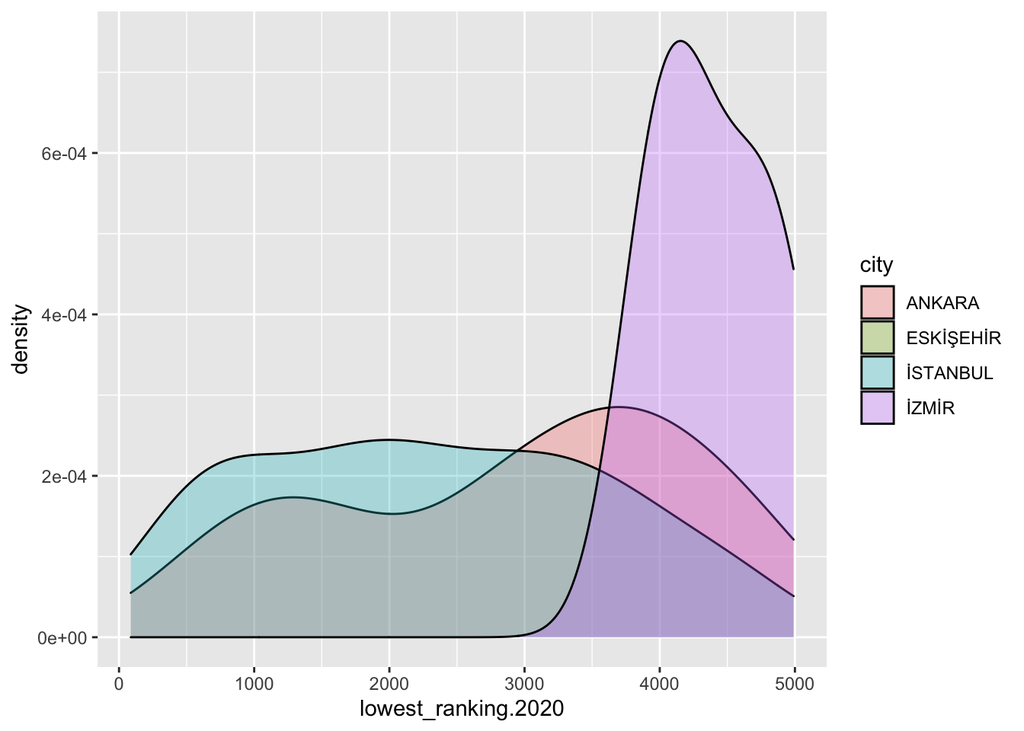

```r
besbin_tr%>%
  ggplot(aes(x = lowest_ranking.2020, fill = city)) +
  geom_density(alpha = 0.3)
```

### Quota Informations

The cities, universities and departments with the highest quotas in recent years can be seen from the tables below.

```r
all_years_data<-bind_rows(mutate(data2016,year=2016),
mutate(data2017,year=2017),
mutate(data2018,year=2018),
mutate(data2019,year=2019),
mutate(data2020,year=2020))

  all_years_data%>%
  group_by(year,department)%>%
  summarise(department_quota=sum(quota))%>%
   arrange(desc(department_quota))%>%head(20)
```

```
## # A tibble: 20 x 3
## # Groups:   year [5]
##     year department            department_quota
##    <dbl> <chr>                            <dbl>
##  1  2020 Hemşirelik                       12469
##  2  2019 Hemşirelik                       11994
##  3  2017 İşletme (Açıköğretim)            11788
##  4  2018 Hemşirelik                       11629
##  5  2017 Hemşirelik                       11306
##  6  2016 Hemşirelik                       10921
##  7  2020 Tıp Fakültesi                    10702
##  8  2019 Tıp Fakültesi                    10203
##  9  2018 Tıp Fakültesi                     9648
## 10  2017 İşletme                           9628
## 11  2016 İşletme                           9481
## 12  2016 İşletme (Açıköğretim)             9226
## 13  2017 Tıp Fakültesi                     9029
## 14  2017 İktisat                           8840
## 15  2019 İlahiyat                          8698
## 16  2018 İşletme                           8593
## 17  2016 İktisat                           8591
## 18  2020 İlahiyat                          8573
## 19  2018 İlahiyat                          8558
## 20  2017 İlahiyat                          8501
```

```r
 all_years_data%>%
  group_by(year,city)%>%
  summarise(city_quota=sum(quota))%>%
  arrange(desc(city_quota))%>%head(20)
```

```
## # A tibble: 20 x 3
## # Groups:   year [5]
##     year city      city_quota
##    <dbl> <chr>          <dbl>
##  1  2018 İSTANBUL      112514
##  2  2020 İSTANBUL      106565
##  3  2019 İSTANBUL      102296
##  4  2017 İSTANBUL      101551
##  5  2016 İSTANBUL       94271
##  6  2017 ESKİŞEHİR      65815
##  7  2016 ESKİŞEHİR      52348
##  8  2020 ANKARA         45092
##  9  2019 ANKARA         40273
## 10  2018 ANKARA         40069
## 11  2018 ESKİŞEHİR      38118
## 12  2017 ANKARA         37907
## 13  2016 ANKARA         35065
## 14  2019 ESKİŞEHİR      29768
## 15  2020 ESKİŞEHİR      26229
## 16  2020 İZMİR          23462
## 17  2019 İZMİR          22564
## 18  2018 İZMİR          22163
## 19  2020 ERZURUM        21999
## 20  2017 İZMİR          19236
```

```r
  all_years_data%>%
  group_by(year,university)%>%
  summarise(university_quota=sum(quota))%>%
  arrange(desc(university_quota))%>%head(20)
```

```
## # A tibble: 20 x 3
## # Groups:   year [5]
##     year university            university_quota
##    <dbl> <chr>                            <dbl>
##  1  2017 ANADOLU ÜNİVERSİTESİ             61485
##  2  2016 ANADOLU ÜNİVERSİTESİ             48110
##  3  2018 ANADOLU ÜNİVERSİTESİ             32351
##  4  2019 ANADOLU ÜNİVERSİTESİ             24057
##  5  2018 İSTANBUL ÜNİVERSİTESİ            22687
##  6  2020 ATATÜRK ÜNİVERSİTESİ             21203
##  7  2020 ANADOLU ÜNİVERSİTESİ             20939
##  8  2017 İSTANBUL ÜNİVERSİTESİ            18309
##  9  2016 İSTANBUL ÜNİVERSİTESİ            18169
## 10  2018 ATATÜRK ÜNİVERSİTESİ             15735
## 11  2020 İSTANBUL ÜNİVERSİTESİ            15283
## 12  2019 İSTANBUL ÜNİVERSİTESİ            15115
## 13  2016 ATATÜRK ÜNİVERSİTESİ             14239
## 14  2019 ATATÜRK ÜNİVERSİTESİ             13663
## 15  2017 ATATÜRK ÜNİVERSİTESİ             13524
## 16  2017 SELÇUK ÜNİVERSİTESİ               9738
## 17  2016 SELÇUK ÜNİVERSİTESİ               8364
## 18  2020 ANKARA ÜNİVERSİTESİ               8196
## 19  2018 SELÇUK ÜNİVERSİTESİ               8162
## 20  2017 GAZİ ÜNİVERSİTESİ                 8055
```

In some cases we would wonder the departments whose quote more increased or decreased. However, there are some highly volatile departments ending with "(Açıköğretim) , (İÖ) or (..indirimli). they may be misleading, so we should eliminate the departments ending with these words in order to get more established departments. Also another criteria can be necessity of being founded at least 4 years ago. So that we can see trends of department quotes. Here is the top 20 departments whose quote increased most and whose decreased most in the last 4 years. Note: Ranked by taking mean quote differences of last 4 years.

```r
quote_by_dept <- all_years_data%>%
  group_by(year,department)%>%
  summarise(department_quota=sum(quota))

quote_by_dept <- data.frame(quote_by_dept) #after group_by we should convert it to df.
quote_by_dept <- quote_by_dept %>%
    group_by(department) %>%
    mutate(Diff = department_quota - lag(department_quota)) %>% arrange(desc(Diff))
quote_by_dept <- data.frame(quote_by_dept) # Again convert to df

quote_by_dept <- quote_by_dept %>% subset(!substr(department,nchar(department)-1,nchar(department)) %in% c("i)","m)","Ö)")) # eliminating some departments
# Also eliminating new founded departments
quote_by_dept <- quote_by_dept %>% group_by(department) %>% filter(n()>= 4)

quote_by_dept <- data.frame(quote_by_dept) # Again convert to df

quote_by_dept %>% group_by(department) %>% summarise(mean_differnce=mean(Diff,na.rm = T)) %>% arrange(desc(mean_differnce)) %>% head(20)#top 20 dept increased quota
```

```
## # A tibble: 20 x 2
##    department                            mean_differnce
##    <chr>                                          <dbl>
##  1 Tıp Fakültesi                                   578.
##  2 Psikoloji                                       464.
##  3 Diş Hekimliği Fakültesi                         462.
##  4 Sağlık Yönetimi                                 461.
##  5 Finans ve Bankacılık                            454.
##  6 Gastronomi ve Mutfak Sanatları                  424.
##  7 İslami İlimler                                  391.
##  8 Bilgisayar Mühendisliği                         388
##  9 Hemşirelik                                      387
## 10 Mimarlık                                        370.
## 11 Beslenme ve Diyetetik                           344.
## 12 Fizyoterapi ve Rehabilitasyon                   342
## 13 Radyo, Televizyon ve Sinema                     317.
## 14 İngiliz Dili ve Edebiyatı (İngilizce)           294
## 15 Rehberlik ve Psikolojik Danışmanlık             293
## 16 Sosyal Hizmet                                   282.
## 17 Siyaset Bilimi ve Kamu Yönetimi                 266.
## 18 Matematik                                       257.
## 19 Türk Dili ve Edebiyatı                          236.
## 20 Hukuk Fakültesi                                 224.
```

```r
quote_by_dept %>% group_by(department) %>% summarise(mean_differnce=mean(Diff,na.rm = T)) %>% arrange(desc(mean_differnce)) %>% tail(20)#20 dept with most decrease in quota
```

```
## # A tibble: 20 x 2
##    department                                       mean_differnce
##    <chr>                                                     <dbl>
##  1 Kimya Mühendisliği                                        -88
##  2 İmalat Mühendisliği                                       -90.5
##  3 Sosyal Bilgiler Öğretmenliği                              -92.5
##  4 Jeoloji Mühendisliği                                      -94.8
##  5 Turizm İşletmeciliği ve Otelcilik                         -97.7
##  6 Ekonometri                                               -100
##  7 Makine Mühendisliği                                      -105
##  8 Konaklama İşletmeciliği                                  -159.
##  9 Metalurji ve Malzeme Mühendisliği                        -172.
## 10 Uluslararası Ticaret                                     -185.
## 11 Enerji Sistemleri Mühendisliği                           -192.
## 12 Kamu Yönetimi                                            -216
## 13 Arkeoloji                                                -219
## 14 Sınıf Öğretmenliği                                       -237.
## 15 Çevre Mühendisliği                                       -417.
## 16 Gıda Mühendisliği                                        -450
## 17 Fen Bilgisi Öğretmenliği                                 -457
## 18 Bilgisayar ve Öğretim Teknolojileri Öğretmenliği         -577
## 19 İktisat                                                  -736.
## 20 İşletme                                                  -790.
```

## References

[*Hacettepe University’s Website*](http://web.ee.hacettepe.edu.tr/osym/).